# Edge - Array analysis of inner ear cells

Meeta Mistry

Array analysis for Judith Kempfle (Judith_Kempfle@MEEI.HARVARD.EDU) at HSCI - Edge Lab. Contact Meeta Mistry (mmistry@hsph.harvard.edu) for additional details. Request from client was:

> Arrays run on Mouse Ref 8 v2.0 Expression Array Ambion to make the following comparisons:
> 1. Compare our postnatal supporting cells to the more stem cell like proliferating (Lgr5+) cells to assess stem cell potential of supporting cells (Sox2-GFP)
> 2. Compare our stem cell derived hair cells to the actual hair cells and make an assumption about their maturity (Atoh1 primary vs. Atoh1 derived). Additionally check how different they are from the supporting-like stem cells from which they were derived
> 3. Compare hair cells and supporting cells (Atoh1-GFP vs. Sox2-GFP)

## Workflow

- Load in expression data and metadata
- Extract relevant information
- Make requested comparisons

## Setup

### Bioconductor and R libraries used

```r
loadlibs <- function(){
library(Biobase)
library(limma)
library(lattice)
library(ggplot2)
library(RColorBrewer)
library(arrayQualityMetrics)
library(reshape)
library(dplyr)
library(beadarray)
library(CHBUtils)
library(knitr)
library(gridExtra)
library(treemap)
library(gProfileR)
source('revigo.R') ## for GO analysis
}
suppressPackageStartupMessages(loadlibs())
```

### Get variables

- get base directory for analyses
- specify data and results directories
- specify column headers used in metadata file

```r
# Setup directory variables
baseDir <- '.'
dataDir <- file.path(baseDir, "data")
metaDir <- file.path(baseDir, "meta")
resultsDir <- file.path(baseDir, "results")
```

## Load Data

We used the R package [beadarray](http://www.bioconductor.org/packages/release/bioc/vignettes/beadarray/inst/doc/beadsummary.pdf) to load in the data and extract the approapriate information. Data can be loaded via IDAT files or from the files generated in GenomeStudio. We need the “bead summary” data which is the final intensity value for all beads of a particular type (foreground minus backround) after outlier removal. Using GenomeStudio file has the advantage of including quality control information used for diagnostic plots. We tried both methods here.

```r
# Get path for all .idat files
dirlist <- scan(file.path(dataDir, "directories.txt"))
filenames = lapply(dirlist, function(x){
    path <- file.path(dataDir, x)
    files <- list.files(path=path, pattern=".idat")
    return(paste0(path, "/", files))})
filenames <- unlist(filenames)

# Create ExpressionSet Illumina object
beadData.idat <- readIdatFiles(filenames)

# OR Not using IDAT files
datafile <- file.path(metaDir, "sample_probe_profile.csv")
qcfile <- file.path(metaDir, "control_probes.csv")
beadData <- readBeadSummaryData(dataFile = datafile, qcFile = qcfile, sep=",", ProbeID = "PROBE_ID", skip = 0,
                                columns = list(exprs = "AVG_Signal", Detection = "Detection_Pval", se.exprs = "BEAD_STDERR",
                                                  nObservations = "Avg_NBEADS"),
                                qc.skip = 0, qc.sep =",", controlID = "ProbeID",
                                qc.columns = list(exprs = "AVG_Signal", Detection = "Detection_Pval"),
                                annoCols=c("PROBE_ID", "SYMBOL","ENTREZ_GENE_ID","CHROMOSOME"))

# Add metadata
meta <- read.csv(file.path(metaDir, '2014-436_sample_key.csv'), header=T)
row.names(meta) <- paste(meta$array, meta$slide, sep="_")
meta <- meta[,-c(1,2)]
pData(beadData) <- meta
```

## Quality control

The raw expression data were run through arrayQualityMetrics to generate various plots and identify potential outlier samples. The report from the quality control can be found at this link. The array intensity distributions and density plots are consistent across samples indicating there are no obvious outlier samples based on expression levels.

```r
 arrayQualityMetrics(expressionset=beadData, intgroup=c('celltype'),
                     outdir='./results/report_aqm_bead', force=TRUE,  do.logtransform=FALSE)
```

## Background correction and normalization (using neqc::limma)

Expression values have not been normalized relative to other arrays, nor background corrected in the sense of negative controls being used to find a baseline. Illumina negative control probes (sequences with no match to the genome) can be used to correct observed signal intensity using a normal exponential convolution model to reduce bias and FPS. A QC report post-normalization can be found here. The resulting expression marix will have negative control probes removed.

```r
bead.norm <- normaliseIllumina(BSData = beadData, method="neqc",
                               status=fData(beadData)$Status, negctrl="NEGATIVE",regular="regular")
```

### PCA

The PCA figure below give us an idea of how samples tend to cluster; illustrating that based on the first and second principal component samples best cluster by celltype. Within the Atoh1 hair cells, we also see separation between those with and without compound. **From the Lgr5+ sample group there is one major outlier (9982502025_D)**. From the inter-correlation heatmap the same sample appears to show a low correlation with all other samples in the dataset. This sample will be removed for downstream analysis.

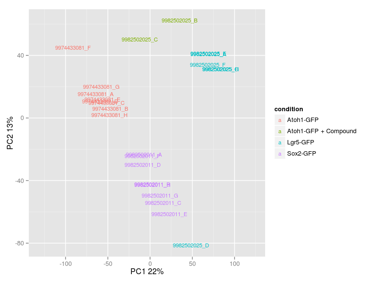

### Sample-to-sample correlation

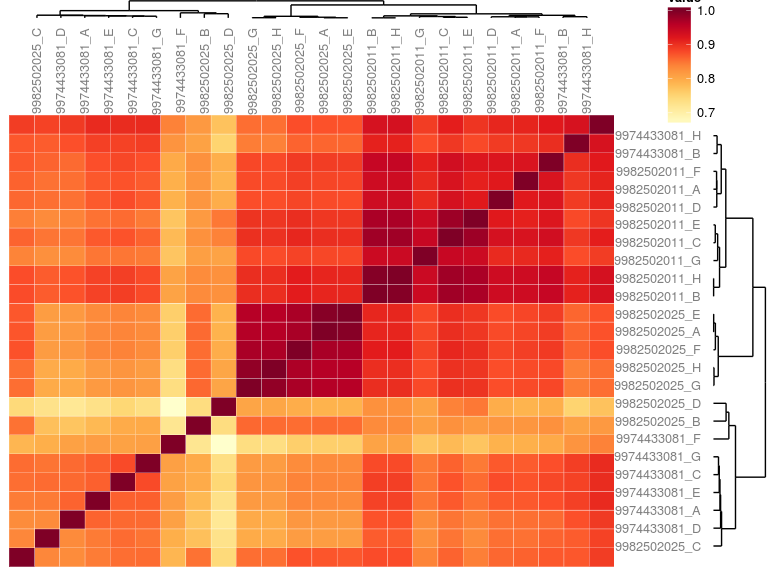

## Postnatal supporting cells versus stem cell-like proliferating Lgr5+ cells

The Lgr5+ cells are made from a original subset of supporting cells put in culture under proliferating conditions. They proliferate like stem cells but retain their supporting cell phenotype- we call them the “dormant stem cells”. They should resemble our Sox2 sorted supporting cells to some extent, but maybe have some more stem cell genes unregulated, as they proliferate.

We set up a design matrix for each comparison and fit a linear model to include array weights. Empirical array quality weights can be used to measure the relative reliability of each array. A variance is estimated for each array by the `arrayWeights` function which measures how well the expression values from each array follow the linear model. These variances are converted to relative weights which can then be used in the linear model to down-weight observations from less reliable arrays which improves power to detect differential expression. We also corrected for the fact that there are technical replicates, so not to treat them as independent samples.

The first comparison below is **(Sox2 vs. Lgr5)**, where we find a total of **672 significant genes** identified at a threshold of **log2FoldChange > 2 and adjusted p-value < 0.05**. The volcano plot below illustrates this with fold change on the x-axis and p-values on the y-axis. The genes that meet the threshold are plotted in green.

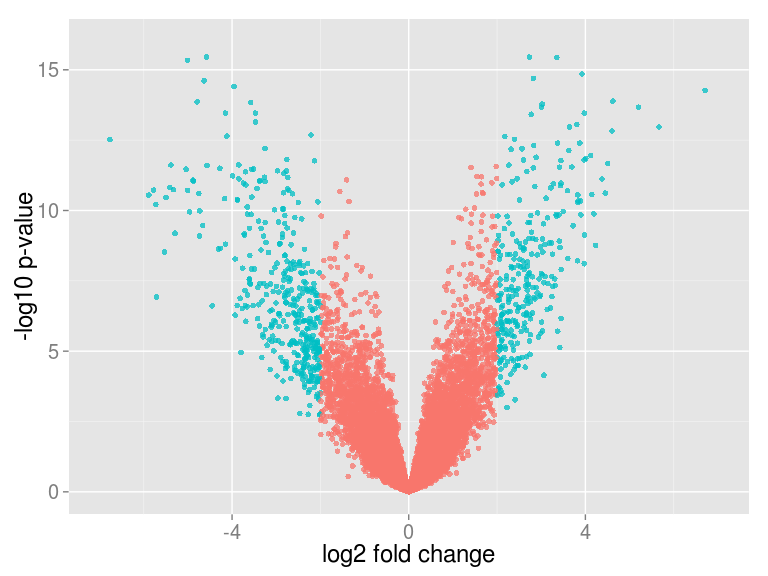

### GO Analysis

Taking our list of significant genes we ran it through [gProfileR](http://biit.cs.ut.ee/gprofiler/), a tool that performs statistical enrichment analysis to find over-representation of information like Gene Ontology terms, biological pathways, regulatory DNA elements, human disease gene annotations, and protein-protein interaction networks.

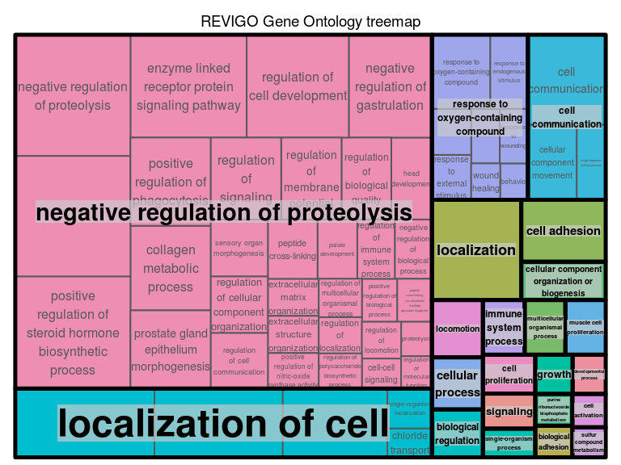

## Hair cells differentiated from supporting-like stem-cells

When the above population (Lgr5+) are differentiated, those supporting cell like stem cells are able to differentiate to a large extent into hair cells. We are able to sort for those “hair cells”, after 10 days in differentiation condition in culture and purified by FACS. These cells should resemble the native Atoh1-GFP+ hair cells we analyzed, but as they come from our stem cell like supporting cells via transdifferentiation we don’t know “how hair cell like” they are.

The next two comparisons are to test stem cell derived hair cells and how different they are from mature hair cells (Atoh1) and how different they are from the supporting like stem cells they were differentiated from (Lgr5+). Using the same threshold as above the mature versus derived cell comaprison identifies **209 significant genes** as differentially expressed with the volcano plots and GO results plotted below.

### Atoh-1 versus Atoh-1 derived

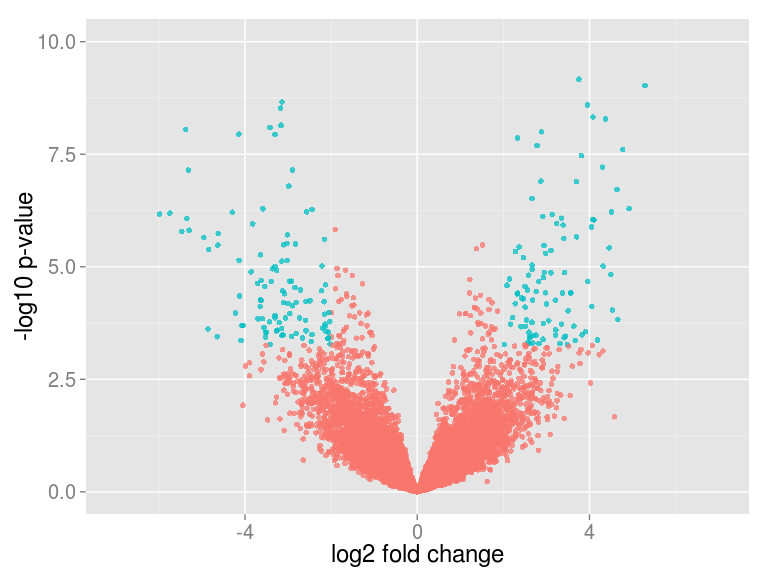

### GO Analysis

The GO results indicate that genes affected between the derived and primary hair cells fall within the categories of ‘response to external stimulus’, groth and death.

[figure not shown]

### Atoh-1 derived cells versus Lgr5+

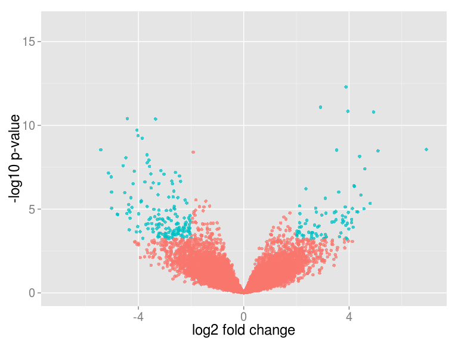

### GO Analysis

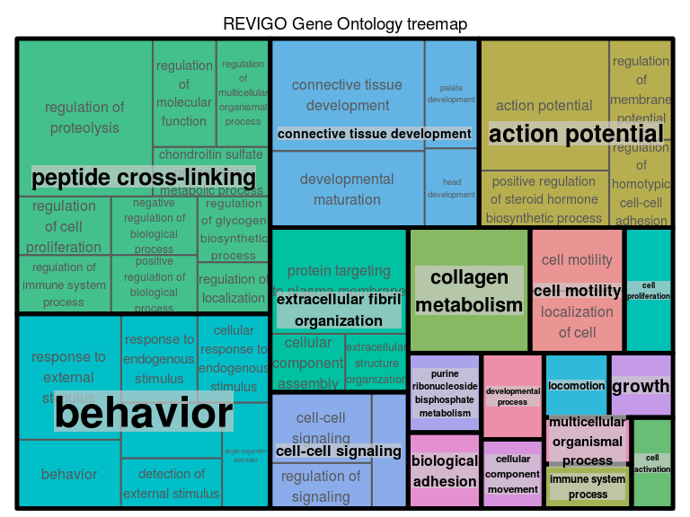

## Hair cells versus Supporting cells

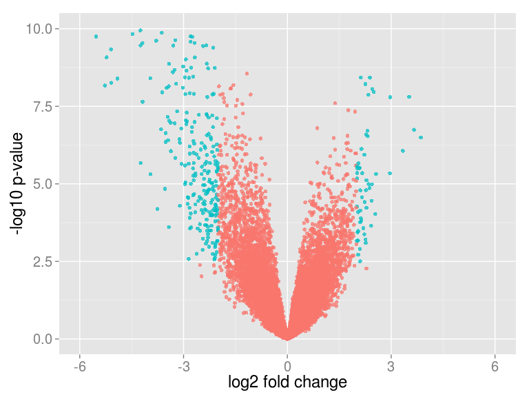

### GO Analysis

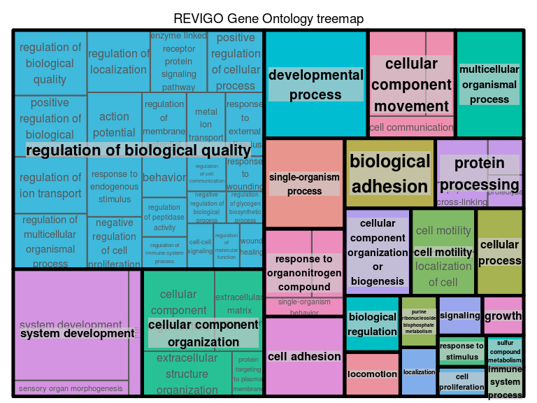

## Incorporating CAGE data

As a first pass we want to investigate whether or not we see any correlation between the CAGE data and gene expression from our microarrays, using TPM as a proxy for gene expression. From the CAGE data we only have two samples that correspond with our microarray data; hair cells (Atoh1-GFP) and supporting cells (Sox-GFP). Taking those two samples we first need to average TPM values across promoters that map to the same gene. We remove those not associated with an EntrezID and those associated with multiple EntrezIDs.

```r
# Load CAGE data
cage_counts <- read.delim("data//mm9.cage_peak_counts.tsv", header=T, sep="\t")
cage_tpm <- read.delim("data//mm9.cage_peak_tpm.tsv", header=T, sep="\t")

# Average by Entrez ID
df <- cage_tpm[,c(5,7:13)]
genemeans <- aggregate(. ~ entrezgene_id, data=df, mean)
genemeans <- genemeans[-1,]

# Extract Entrez ID
ids <- as.numeric(gsub("entrezgene:", "", genemeans$entrezgene_id))
genemeans$entrezgene_id <- ids

# Remove multiple gene mappings
genemeans <- genemeans[which(!is.na(genemeans$entrezgene_id)),]
cage_genes <- genemeans[which(genemeans$entrezgene_id %in% fData(bead.norm)$ENTREZ_GENE_ID),]

# Log transform
logmat <- apply(cage_genes[,2:8], 2, function(x){replace(x, which(x == 0), NA)})
logmat <- log(logmat)
logmat <- cbind(cage_genes$entrezgene_id, logmat)
cage_genes <- logmat
colnames(cage_genes)[1] <- "entrezgene_id"
```

We then take the microarray data and average expression values across sample replicates. Additionally, we average across probes that map to the same gene. We then merge the CAGE and array data on interesecting EntrezGene IDs and compute correlations for hair cells and supporting cells. The scatter plots below illustrate the relationship between the array data and the CAGE data. We used hexbin to plot binned expression since there are a high density of points plotted at the low end of expression (light grey = one data point). The correlation between CAGE and array appear to be reasonably high at a Spearman rank correlation of ~ 0.5.

|  | Spearman Correlation |
| --- | --- |
| Atoh1- CAGE versus Microraray | 0.5243333 |
| Sox21- CAGE versus Microraray | 0.5672399 |

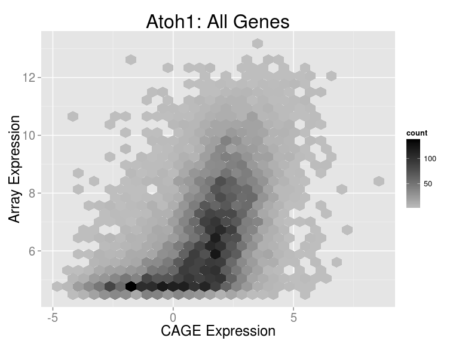

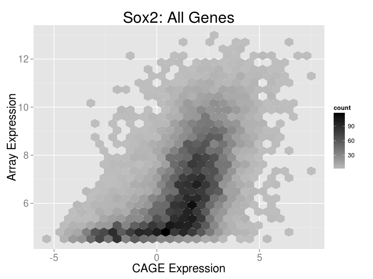

```r
# Average expression values across samples in microarray data
df <- data.frame(t(exprs(bead.norm)), sampletype=pData(bead.norm)$sampletype)
samplemeans <- aggregate(. ~ sampletype, data=df, mean)
samplemeans <- t(samplemeans)
colnames(samplemeans) <- samplemeans[1,]
samplemeans <- samplemeans[-1,]

# Average expression values across probes that map to the same gene
df <- data.frame(entrezgeneID=fData(bead.norm)$ENTREZ_GENE_ID, apply(samplemeans, 2, as.numeric))
array_genes <- aggregate(. ~ entrezgeneID, data=df, mean)
array_genes <- array_genes[which(array_genes$entrezgeneID %in% cage_genes[,'entrezgene_id']),]

# Combine CAGE and array
all_exprs <- merge(cage_genes, array_genes, by.x='entrezgene_id', by.y='entrezgeneID')
colnames(all_exprs)[2] <- "Atoh1_CAGE"
colnames(all_exprs)[8] <- "Sox2_CAGE"
```

## Files for download

Below we have listed links to the various files generated in this report which will be useful for any downstream analysis.

### Data Files

- Normalized expression matrix here
- Metadata file here (containing sample information)
- CAGE expression(log transformed) and average array expression data for intersecting gene set

### DE results

- Atoh1-GFP versus Atoh1-GFP + compound significant genes
- Atoh1-GFP + compound versus Lgr5+ significant genes
- Sox2-GFP versus Lgr5+ significant genes
- Hair cells versus Suporting cells significant genes

### Functional enrichment results

- Atoh1-GFP versus Atoh1-GFP + compound gprofiler
- Atoh1-GFP + compound versus Lgr5+ gprofiler
- Sox2-GFP versus Lgr5+ gprofiler
- Hair cells versus Suporting cells gprofiler